# Minimal Example–Issues Passing dpylr Variable Names

Randi Garcia

6/23/2016

## Original Problem

Below is a broken function for mapping services needed.

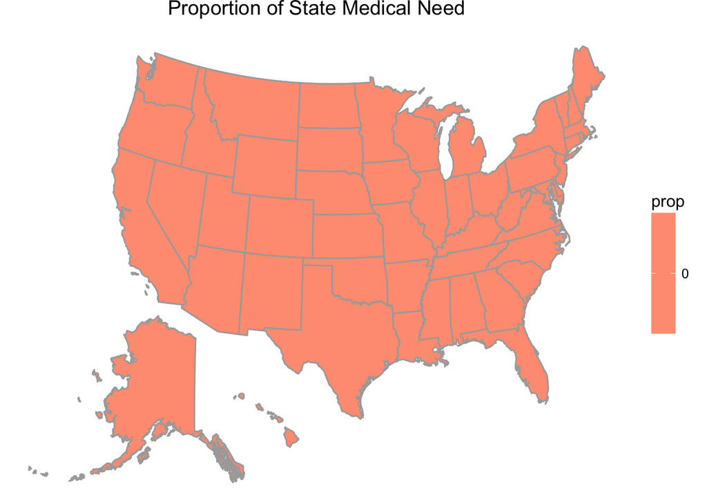

```r
library(mosaic)
load("~/cvc-workshop/perpnew.Rda")

mapPriority <- function(data, sneed = "Medical", vari, colr = "red"){

  propneed <- data %>%
    filter(state != "N/") %>%
    group_by(state) %>%
    summarise(total = n(), need = sum(vari == "(1) Yes")) %>%
    mutate(prop = need/total)

  mUSMap(propneed, key="state", fill = "prop")+
    scale_fill_continuous(low="white", high = colr)+
    ggtitle(paste("Proportion of State", sneed, "Need"))

}

mapPriority(data = perpnew, sneed = "Medical", vari = "FU6P1", colr = "red")
```

Notice that even if we change the variable (`FU6P1` to `FU6P2`), the map doesn’t change.

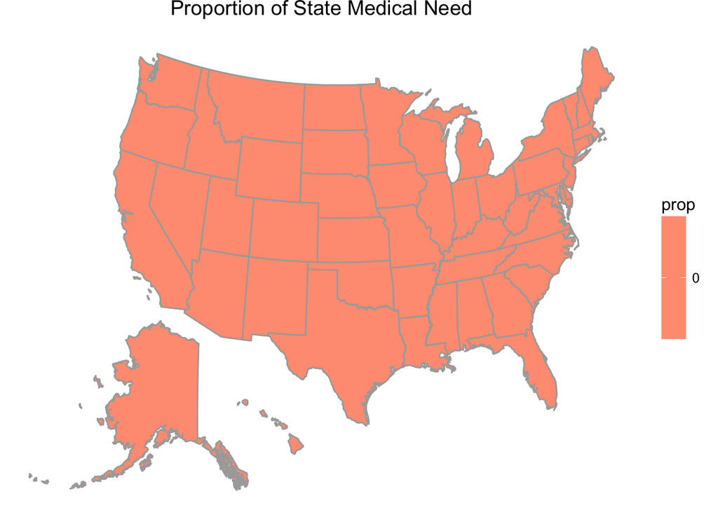

```r
mapPriority(data = perpnew, sneed = "Medical", vari = "FU6P2", colr = "red")
```

But if we add in the `mutate_` function, it does change as expected.

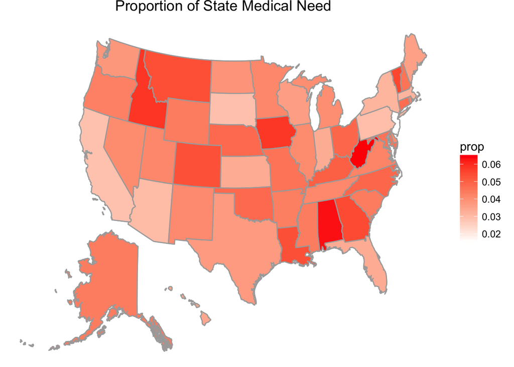

```r
mapPriority <- function(data, sneed = "Medical", vari, colr = "red"){

  propneed <- data %>%
    mutate_(vari=vari) %>%
    filter(state != "N/") %>%
    group_by(state) %>%
    summarise(total = n(), need = sum(vari == "(1) Yes")) %>%
    mutate(prop = need/total)

  mUSMap(propneed, key="state", fill = "prop")+
    scale_fill_continuous(low="white", high = colr)+
    ggtitle(paste("Proportion of State", sneed, "Need"))

}


mapPriority(data = perpnew, sneed = "Medical", vari = "FU6P5", colr = "red")
```

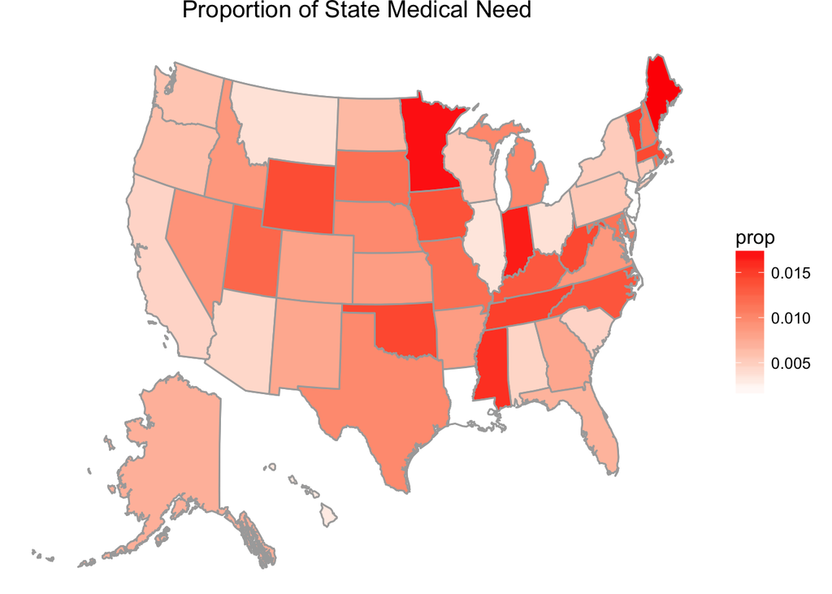

```r
mapPriority(data = perpnew, sneed = "Medical", vari = "FU6P2", colr = "red")
```

The title change and map color change now work fine.

The issue, as I understand it, is with getting summarise() to recogize “vari” as a variable name in “data”. The function summarise() is taking a standard function, n(), and a nonstandard function, sum(). Hypothetically, if we could use summarise_(sum(vari)) and summarise(n()) separately, we’d be OK, but we cannot do that because we want to perform those two function on the same tbl.

## Minimal Example with KidsFeet Data

Because the data from the original example isn’t publically available, so we’ll make a minimal reproducible example.

```r
library(mosaic)

domRights <- function(df, var){

  df %>%
    group_by(sex) %>%
    summarise(sampsize = n(), rights = sum(var == "R"))
}
```

Here are some simple tallies to see what we would expect for number of right bigger feet and right dominate hand for boys and girls separately.

```r
#for expected number of rights
tally(~biggerfoot|sex, data=KidsFeet)
```

```
##           sex
## biggerfoot  B  G
##          L 11 11
##          R  9  8
```

```r
tally(~domhand|sex, data=KidsFeet)
```

```
##        sex
## domhand  B  G
##       L  5  3
##       R 15 16
```

But here is what we get using the broken function above.

```r
domRights(KidsFeet, "biggerfoot")
```

```
## Source: local data frame [2 x 3]
##
##      sex sampsize rights
##   (fctr)    (int)  (int)
## 1      B       20      0
## 2      G       19      0
```

```r
domRights(KidsFeet, "domhand")
```

```
## Source: local data frame [2 x 3]
##
##      sex sampsize rights
##   (fctr)    (int)  (int)
## 1      B       20      0
## 2      G       19      0
```

But it’s fixed if we add the `mutate_` function.

```r
domRights <- function(df, var){

  df %>%
    mutate_(var=var) %>%
    group_by(sex) %>%
    summarise(sampsize = n(), rights = sum(var == "R"))

}

domRights(KidsFeet, "biggerfoot")
```

```
## Source: local data frame [2 x 3]
##
##      sex sampsize rights
##   (fctr)    (int)  (int)
## 1      B       20      9
## 2      G       19      8
```

```r
domRights(KidsFeet, "domhand")
```

```
## Source: local data frame [2 x 3]
##
##      sex sampsize rights
##   (fctr)    (int)  (int)
## 1      B       20     15
## 2      G       19     16
```